# Tarea4_Ricardo_Garbanzo2

Ricardo Garbanzo

19/1/2020

# Ejercicio 2

Punto A Cargue la tabla de datos Datos Churn.csv en R y ejecute un str(…), summary(…) y un dim(…), verifique la correcta lectura de los datos, recuerde que IdCliente es el identificador de fila.

```r
datos <- read.csv("Datos_Churn.csv",header=TRUE, sep=",", dec=".")
str(datos)
```

```
## 'data.frame':    10000 obs. of  13 variables:
##  $ IdCliente        : int  15802207 15725639 15605698 15806913 15613713 15712608 15590286 15785798 15576517 15750258 ...
##  $ Apellido         : Factor w/ 2929 levels "Abazu","Abbie",..: 1264 1275 1124 258 1449 622 845 2669 837 93 ...
##  $ ScoringCrediticio: int  769 793 746 670 644 787 611 850 445 675 ...
##  $ Pais             : Factor w/ 3 levels "Alemania","EspaÃ±a",..: 1 3 3 3 3 1 3 3 1 3 ...
##  $ Genero           : Factor w/ 2 levels "Femenino","Masculino": 2 1 2 1 2 1 1 2 1 1 ...
##  $ Edad             : int  43 63 58 54 30 42 40 40 34 32 ...
##  $ IdCuenta         : int  4426 5052 9306 5935 3328 9269 7503 1452 2582 2129 ...
##  $ BalanceCuenta    : num  110183 116271 0 95507 44929 ...
##  $ CantidadProductos: int  2 1 3 1 1 2 1 2 2 1 ...
##  $ TarjetaCredito   : int  1 1 1 1 1 0 1 0 1 1 ...
##  $ Activo           : int  1 1 1 1 1 1 0 1 1 0 ...
##  $ SalarioEstimado  : num  87537 184243 80345 63213 10771 ...
##  $ DejaBanco        : int  0 0 1 0 0 0 0 0 0 0 ...
```

```r
summary(datos)
```

```
##    IdCliente           Apellido    ScoringCrediticio       Pais
##  Min.   :15565701   Smith  :  32   Min.   :350.0     Alemania:2501
##  1st Qu.:15628526   Martin :  29   1st Qu.:584.0     EspaÃ±a :2468
##  Median :15690695   Scott  :  29   Median :652.0     Francia :5002
##  Mean   :15690910   Walker :  28   Mean   :650.5     NA's    :  29
##  3rd Qu.:15753222   Brown  :  26   3rd Qu.:717.0
##  Max.   :15815690   (Other):9840   Max.   :850.0
##  NA's   :21         NA's   :  16   NA's   :15
##        Genero          Edad          IdCuenta     BalanceCuenta
##  Femenino :4535   Min.   :18.00   Min.   : 1001   Min.   :     0
##  Masculino:5452   1st Qu.:32.00   1st Qu.: 3504   1st Qu.:     0
##  NA's     :  13   Median :37.00   Median : 6005   Median : 97173
##                   Mean   :38.92   Mean   : 6003   Mean   : 76473
##                   3rd Qu.:44.00   3rd Qu.: 8502   3rd Qu.:127638
##                   Max.   :92.00   Max.   :11000   Max.   :250898
##                   NA's   :21      NA's   :21      NA's   :20
##  CantidadProductos TarjetaCredito       Activo       SalarioEstimado
##  Min.   :1.00      Min.   :0.0000   Min.   :0.0000   Min.   :    11.58
##  1st Qu.:1.00      1st Qu.:0.0000   1st Qu.:0.0000   1st Qu.: 51011.29
##  Median :1.00      Median :1.0000   Median :1.0000   Median :100236.02
##  Mean   :1.53      Mean   :0.7057   Mean   :0.5149   Mean   :100111.58
##  3rd Qu.:2.00      3rd Qu.:1.0000   3rd Qu.:1.0000   3rd Qu.:149399.70
##  Max.   :4.00      Max.   :1.0000   Max.   :1.0000   Max.   :199992.48
##  NA's   :15        NA's   :20       NA's   :14       NA's   :15
##    DejaBanco
##  Min.   :0.0000
##  1st Qu.:0.0000
##  Median :0.0000
##  Mean   :0.2038
##  3rd Qu.:0.0000
##  Max.   :1.0000
##  NA's   :24
```

```r
dim(datos)
```

```
## [1] 10000    13
```

```r
#b) Elimine las variables de valor unico, es decir, las variables Apellido y IdCuenta
datos <- datos[, -c(1,4,2,7)]
datos <- na.omit(datos)
str(datos)
```

```
## 'data.frame':    9845 obs. of  9 variables:
##  $ ScoringCrediticio: int  769 793 746 670 644 787 611 850 445 675 ...
##  $ Genero           : Factor w/ 2 levels "Femenino","Masculino": 2 1 2 1 2 1 1 2 1 1 ...
##  $ Edad             : int  43 63 58 54 30 42 40 40 34 32 ...
##  $ BalanceCuenta    : num  110183 116271 0 95507 44929 ...
##  $ CantidadProductos: int  2 1 3 1 1 2 1 2 2 1 ...
##  $ TarjetaCredito   : int  1 1 1 1 1 0 1 0 1 1 ...
##  $ Activo           : int  1 1 1 1 1 1 0 1 1 0 ...
##  $ SalarioEstimado  : num  87537 184243 80345 63213 10771 ...
##  $ DejaBanco        : int  0 0 1 0 0 0 0 0 0 0 ...
##  - attr(*, "na.action")= 'omit' Named int  45 61 107 201 228 239 308 390 405 531 ...
##   ..- attr(*, "names")= chr  "45" "61" "107" "201" ...
```

```r
# C) Asegurese re-codificar las variables que sean cualitativas y que esten codificadas en el
# archivo con numeros; lo cual causa que R interprete incorrectamente el tipo de la variable,
# es decir, las variables TarjetaCredito, Activo y DejaBanco.

datos$TarjetaCredito <- factor(datos$TarjetaCredito, ordered = T)
datos$Activo <- factor(datos$Activo, ordered = T)
datos$DejaBanco <- factor(datos$DejaBanco, ordered = T)
str(datos)
```

```
## 'data.frame':    9845 obs. of  9 variables:
##  $ ScoringCrediticio: int  769 793 746 670 644 787 611 850 445 675 ...
##  $ Genero           : Factor w/ 2 levels "Femenino","Masculino": 2 1 2 1 2 1 1 2 1 1 ...
##  $ Edad             : int  43 63 58 54 30 42 40 40 34 32 ...
##  $ BalanceCuenta    : num  110183 116271 0 95507 44929 ...
##  $ CantidadProductos: int  2 1 3 1 1 2 1 2 2 1 ...
##  $ TarjetaCredito   : Ord.factor w/ 2 levels "0"<"1": 2 2 2 2 2 1 2 1 2 2 ...
##  $ Activo           : Ord.factor w/ 2 levels "0"<"1": 2 2 2 2 2 2 1 2 2 1 ...
##  $ SalarioEstimado  : num  87537 184243 80345 63213 10771 ...
##  $ DejaBanco        : Ord.factor w/ 2 levels "0"<"1": 1 1 2 1 1 1 1 1 1 1 ...
##  - attr(*, "na.action")= 'omit' Named int  45 61 107 201 228 239 308 390 405 531 ...
##   ..- attr(*, "names")= chr  "45" "61" "107" "201" ...
```

4. El objetivo de este ejercicio es calibrar el metodo de ADA para esta Tabla de Datos. Aqui interesa predecir en la variable DejaBanco que indica si el cliente deja sus negocios con el banco (1) o no (0). Para esto genere 5 Validaciones Cruzadas con 10 grupos calibrando el modelo de acuerdo con los tres tipos de algoritmos que permite, discrete, real y gentle. Para medir la calidad de metodo sume la cantidad de 1’s detectados en los diferentes grupos. Luego grafique las 5 iteraciones para los tres algoritmos en el mismo grafico. ¿Se puede determinar con claridad cual algoritmo es el mejor? Para generar los modelos predictivos use el paquete traineR.

```r
library(caret)
library(traineR)
summary(datos)
```

```
##  ScoringCrediticio       Genero          Edad       BalanceCuenta
##  Min.   :350.0     Femenino :4474   Min.   :18.00   Min.   :     0
##  1st Qu.:584.0     Masculino:5371   1st Qu.:32.00   1st Qu.:     0
##  Median :652.0                      Median :37.00   Median : 97023
##  Mean   :650.4                      Mean   :38.94   Mean   : 76342
##  3rd Qu.:717.0                      3rd Qu.:44.00   3rd Qu.:127553
##  Max.   :850.0                      Max.   :92.00   Max.   :250898
##  CantidadProductos TarjetaCredito Activo   SalarioEstimado     DejaBanco
##  Min.   :1.000     0:2898         0:4778   Min.   :    11.58   0:7838
##  1st Qu.:1.000     1:6947         1:5067   1st Qu.: 51219.80   1:2007
##  Median :1.000                             Median :100408.31
##  Mean   :1.532                             Mean   :100172.50
##  3rd Qu.:2.000                             3rd Qu.:149418.41
##  Max.   :4.000                             Max.   :199992.48
```

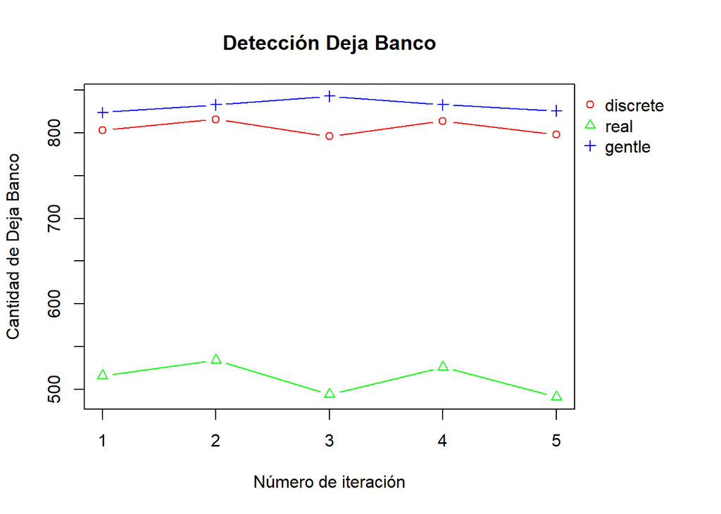

```r
numero.filas <- nrow(datos)
cantidad.validacion.cruzada <- 5
cantidad.grupos <- 10

deteccion.si.discrete <- c()
deteccion.si.real <- c()
deteccion.si.gentle <- c()

for(i in 1:cantidad.validacion.cruzada){
  grupos  <- createFolds(1:numero.filas, cantidad.grupos)
  si.discrete <- 0
  si.real <- 0
  si.gentle <- 0


  for(k in 1:cantidad.grupos) {
    muestra <- grupos[[k]]
    ttesting <- datos[muestra, ]
    taprendizaje <- datos[-muestra, ]

    modelo <- train.ada(formula = DejaBanco ~ ., data = taprendizaje, iter = 10 , type = 'discrete')
    prediccion <- predict(modelo, ttesting)
    MC <- confusion.matrix(ttesting, prediccion)
    si.discrete <- si.discrete + MC[2, 2] # Detección DejaBanco

    modelo <- train.ada(formula = DejaBanco ~ ., data = taprendizaje, iter = 10, type = 'real')
    prediccion <- predict(modelo, ttesting)
    MC <- confusion.matrix(ttesting, prediccion)
    si.real <- si.real + MC[2, 2] # Detección DejaBanco

    modelo <- train.ada(formula = DejaBanco ~ ., data = taprendizaje, iter = 10, type = 'gentle' )
    prediccion <- predict(modelo, ttesting)
    MC <- confusion.matrix(ttesting, prediccion)
    si.gentle <- si.gentle + MC[2, 2] # Detección DejaBanco

  }

  deteccion.si.discrete[i] <- si.discrete
  deteccion.si.real[i] <- si.real
  deteccion.si.gentle[i] <- si.gentle

}


resultados <- data.frame("discrete"     = deteccion.si.discrete,
                         "real"     = deteccion.si.real,
                         "gentle" = deteccion.si.gentle) # Preparamos los datos

par(oma=c(0, 0, 0, 5)) # Hace espacio para la leyenda

matplot(resultados, type="b", lty = 1, lwd = 1, pch = 1:ncol(resultados),
        main = "Detección Deja Banco",
        xlab = "Número de iteración",
        ylab = "Cantidad de Deja Banco",
        col = rainbow(ncol(resultados)))
legend(par('usr')[2], par('usr')[4], legend = colnames(resultados),bty='n', xpd=NA,
       pch=1:ncol(resultados), col = rainbow(ncol(resultados))) # La leyenda
```

## El algorimo de gentle se coloca como la mejor predicción del si

5. Repita el ejercicio anterior, pero esta vez en lugar de sumar la cantidad de 1’s, promedie los errores globales cometidos en los diferentes grupos (folds). Luego grafique las 5 iteraciones para los tres algoritmos en el mismo grafico. ¿Se puede determinar con claridad cual algoritmo es el mejor?

```r
#calculo de indices
indices.general <- function(MC) {
  precision.global <- sum(diag(MC))/sum(MC)
  error.global <- 1 - precision.global
  precision.categoria <- diag(MC)/rowSums(MC)
  res <- list(matriz.confusion = MC, precision.global = precision.global, error.global = error.global,
              precision.categoria = precision.categoria)
  names(res) <- c("Matriz de Confusión", "Precisión Global", "Error Global",
                  "Precisión por categoría")
  return(res)
}

library(caret)
library(traineR)
datos <- read.csv("Datos_Churn.csv",header=TRUE, sep=",", dec=".")

datos <- datos[, -c(1,4,2,7)]
datos <- na.omit(datos)
str(datos)
```

```
## 'data.frame':    9845 obs. of  9 variables:
##  $ ScoringCrediticio: int  769 793 746 670 644 787 611 850 445 675 ...
##  $ Genero           : Factor w/ 2 levels "Femenino","Masculino": 2 1 2 1 2 1 1 2 1 1 ...
##  $ Edad             : int  43 63 58 54 30 42 40 40 34 32 ...
##  $ BalanceCuenta    : num  110183 116271 0 95507 44929 ...
##  $ CantidadProductos: int  2 1 3 1 1 2 1 2 2 1 ...
##  $ TarjetaCredito   : int  1 1 1 1 1 0 1 0 1 1 ...
##  $ Activo           : int  1 1 1 1 1 1 0 1 1 0 ...
##  $ SalarioEstimado  : num  87537 184243 80345 63213 10771 ...
##  $ DejaBanco        : int  0 0 1 0 0 0 0 0 0 0 ...
##  - attr(*, "na.action")= 'omit' Named int  45 61 107 201 228 239 308 390 405 531 ...
##   ..- attr(*, "names")= chr  "45" "61" "107" "201" ...
```

```r
datos$TarjetaCredito <- factor(datos$TarjetaCredito, ordered = T)
datos$Activo <- factor(datos$Activo, ordered = T)
datos$DejaBanco <- factor(datos$DejaBanco, ordered = T)
str(datos)
```

```
## 'data.frame':    9845 obs. of  9 variables:
##  $ ScoringCrediticio: int  769 793 746 670 644 787 611 850 445 675 ...
##  $ Genero           : Factor w/ 2 levels "Femenino","Masculino": 2 1 2 1 2 1 1 2 1 1 ...
##  $ Edad             : int  43 63 58 54 30 42 40 40 34 32 ...
##  $ BalanceCuenta    : num  110183 116271 0 95507 44929 ...
##  $ CantidadProductos: int  2 1 3 1 1 2 1 2 2 1 ...
##  $ TarjetaCredito   : Ord.factor w/ 2 levels "0"<"1": 2 2 2 2 2 1 2 1 2 2 ...
##  $ Activo           : Ord.factor w/ 2 levels "0"<"1": 2 2 2 2 2 2 1 2 2 1 ...
##  $ SalarioEstimado  : num  87537 184243 80345 63213 10771 ...
##  $ DejaBanco        : Ord.factor w/ 2 levels "0"<"1": 1 1 2 1 1 1 1 1 1 1 ...
##  - attr(*, "na.action")= 'omit' Named int  45 61 107 201 228 239 308 390 405 531 ...
##   ..- attr(*, "names")= chr  "45" "61" "107" "201" ...
```

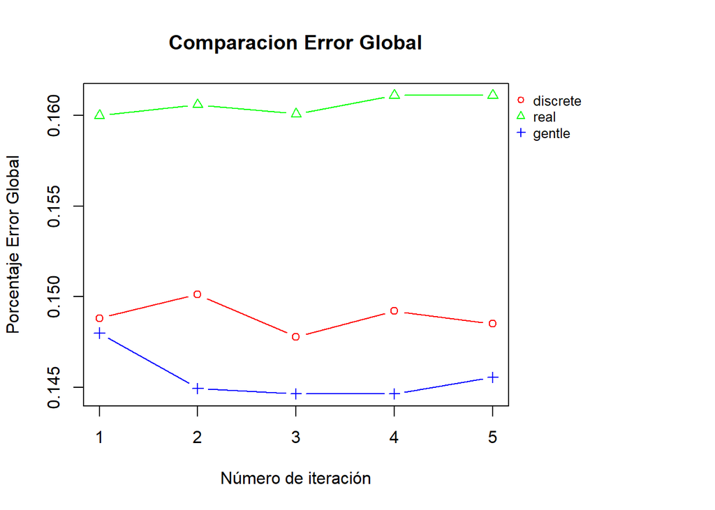

```r
numero.filas <- nrow(datos)
cantidad.validacion.cruzada <-5
cantidad.grupos <- 10

deteccion.error.discrete <- c()
deteccion.error.real <- c()
deteccion.error.gentle <- c()

for(i in 1:cantidad.validacion.cruzada){
  grupos  <- createFolds(1:numero.filas, cantidad.grupos)
  error.discrete <- 0
  error.real <- 0
  error.gentle <- 0


  for(k in 1:cantidad.grupos) {
    muestra <- grupos[[k]]
    ttesting <- datos[muestra, ]
    taprendizaje <- datos[-muestra, ]

    modelo <- train.ada(formula = DejaBanco ~ ., data = taprendizaje, iter = 10 , type = 'discrete')
    prediccion <- predict(modelo, ttesting)
    MC <- confusion.matrix(ttesting, prediccion)
    Error.Global <- indices.general(MC)
    error.discrete <- error.discrete + Error.Global$`Error Global` # Detección DejaBanco

    modelo <- train.ada(formula = DejaBanco ~ ., data = taprendizaje, iter = 10, type = 'real')
    prediccion <- predict(modelo, ttesting)
    MC <- confusion.matrix(ttesting, prediccion)
    Error.Global <- indices.general(MC)
    error.real <- error.real + Error.Global$`Error Global` # Detección DejaBanco

    modelo <- train.ada(formula = DejaBanco ~ ., data = taprendizaje, iter = 10, type = 'gentle' )
    prediccion <- predict(modelo, ttesting)
    MC <- confusion.matrix(ttesting, prediccion)
    Error.Global <- indices.general(MC)
    error.gentle <- error.gentle + Error.Global$`Error Global` # Detección DejaBanco

  }

  error.discrete <- error.discrete/10
  error.real <- error.real/10
  error.gentle <- error.gentle/10

  deteccion.error.discrete[i] <- error.discrete
  deteccion.error.real[i] <- error.real
  deteccion.error.gentle[i] <- error.gentle

}




resultados <- data.frame("discrete" = deteccion.error.discrete,
                         "real" = deteccion.error.real,
                         "gentle" = deteccion.error.gentle) # Preparamos los datos

par(oma=c(0, 0, 0, 8)) # Hace espacio para la leyenda

matplot(resultados, type="b", lty = 1, lwd = 1, pch = 1:ncol(resultados),
        main = "Comparacion Error Global",
        xlab = "Número de iteración",
        ylab = "Porcentaje Error Global",
        col = rainbow(ncol(resultados)))
legend(par('usr')[2], par('usr')[4], legend = colnames(resultados),bty='n', xpd=NA, cex = 0.8,
       pch=1:ncol(resultados), col = rainbow(ncol(resultados))) # La leyenda
```

## El Analizar el error global se obtiene un menor error global con el algoritmo de gentle